# Month 4 methodology: emerging occupation clusters

Author

Antonis Prodromou

Published

November 27, 2026

# 1 Month 4 methodology: emerging occupation clusters

This part of the project aims to detect emerging occupations via clustering, using the dataset defined in the previous parts, and more specifically:

1. We use the titles of the postings retrieved from the Skillab API and we create embeddings for each, using multilingual-e5, which is a family of open-source text embedding models designed for cross-lingual semantic search, information retrieval, and text representation. These models are built on the XLM-RoBERTa architecture, while the model sized used has 560M parameters and a 1024-dimensional embedding space.
2. In the next step, we create clusters using HDBSCAN, a machine learning clustering algorithm that handles clusters of different shapes and densities. We also create a two-dimensional visualisation of the occupation clusters to check whether the clustering results are reasonable, using Uniform Manifold Approximation and Projection (UMAP). As the embeddings have 1024 dimensions, we use UMAP to represent them in fewer dimensions while attempting to preserve their local neighbourhood structure, and plot the postings on a scatter plot. We also use K-means as a comparison, to assess whether HDBSCAN is producing useful clusters compared with a more traditional clustering algorithm.
3. In the final step, we check whether specific occupations related to deglobalization belong or form their own clusters, and record their development over quarters between 2024 and 2026. Finally, we will calculate the Herfindahl Hirschman Index (HHI)[^1] per region and cluster, as well as an Occupation Emergence Rate per cluster.

## 1.1 Data used

The data collected in this part of the study covers the periods before (defined as “baselines”) and after specific deglobalization policy events. The analysis of Month 2 (Table 1) showed that no board had an adequate number of postings prior to 2024, to be used for analysis:

Table 1: Monthly job posting counts across platforms.

| Month | `eures` | `eures-esco` | `kariera.gr` (GR) | `lesjeudis.com` (FR) | `jobbland.se` (SE) | `jobs.de` (DE) | `kariera.fr` (FR) |
| --- | --- | --- | --- | --- | --- | --- | --- |
| 2024-01 | 1 | 0 | 0 | 0 | 191 | 0 | 0 |
| 2024-02 | 0 | 1 | 0 | 0 | 246 | 0 | 0 |
| 2024-03 | 22 | 24 | 0 | 0 | 292 | 0 | 0 |
| 2024-04 | 2 | 1 | 0 | 0 | 410 | 0 | 0 |
| 2024-05 | 36 | 22 | 0 | 0 | 2,116 | 0 | 0 |
| 2024-06 | 3 | 4 | 0 | 0 | 2,879 | 0 | 0 |
| 2024-07 | 7 | 2 | 0 | 0 | 2,060 | 0 | 0 |
| 2024-08 | 4 | 6 | 2,738 | 5,660 | 4,184 | 3,427 | 3,000 |
| 2024-09 | 6 | 5 | 5,629 | 6,649 | 10,034 | 5,632 | 27,099 |
| 2024-10 | 5 | 6 | 5,480 | 4,935 | 48,018 | 8,175 | 32,892 |
| 2024-11 | 13 | 17 | 5,593 | 3,986 | 50,097 | 6,417 | 7,043 |
| 2024-12 | 37 | 62 | 4,866 | 3,511 | 47,151 | 4,029 | 4,941 |
| 2025-01 | 270 | 495 | 7,065 | 4,191 | 53,139 | 1,690 | 6,054 |
| 2025-02 | 20 | 18 | 3,174 | 1,548 | 23,017 | 2,572 | 4,916 |
| 2025-03 | 96 | 62 | 2,884 | 450 | 10,959 | 1,691 | 523 |
| 2025-04 | 120 | 93 | 1,458 | 581 | 4,139 | 597 | 0 |
| 2025-05 | 91 | 91 | 4,219 | 2,336 | 6,210 | 0 | 0 |
| 2025-06 | 64 | 78 | 4,678 | 3,887 | 132 | 0 | 0 |
| 2025-07 | 81 | 130 | 4,097 | 800 | 460 | 0 | 0 |
| 2025-08 | 148 | 234 | 3,510 | 3,383 | 3,066 | 0 | 0 |
| 2025-09 | 937 | 1,610 | 1,703 | 3,279 | 3,968 | 0 | 0 |
| 2025-10 | 1,523 | 6,335 | 61 | 1,476 | 1,520 | 0 | 0 |
| 2025-11 | 15,811 | 23,611 | 37 | 738 | 3,618 | 0 | 0 |
| 2025-12 | 21,926 | 29,746 | 3,308 | 386 | 28,639 | 0 | 0 |
| 2026-01 | 99,039 | 130,320 | 7,112 | 250 | 48,511 | 0 | 0 |
| 2026-02 | 260,792 | 698,166 | 6,542 | 6,561 | 55,457 | 0 | 0 |
| 2026-03 | 0 | 0 | 6,953 | 768 | 62,392 | 0 | 0 |
| 2026-04 | 0 | 0 | 6,659 | 0 | 47,721 | 0 | 0 |
| 2026-05 | 0 | 0 | 0 | 0 | 53,794 | 0 | 0 |
| 2026-06 | 0 | 0 | 0 | 0 | 46,127 | 0 | 0 |
| 2026-07 | 0 | 0 | 0 | 0 | 31,166 | 0 | 0 |
| 2026-08 | 0 | 0 | 0 | 0 | 40,875 | 0 | 0 |
| 2026-09 | 0 | 0 | 0 | 0 | 595 | 0 | 0 |

Our work therefore focuses on two events, using two of these boards: AccelerateEU (22 April 2026) on jobbland.se and InvestAI (11 February 2025) on lesjeudis.com. It is important to note that the postings of the individual boards are examined separately and are not merged.

## 1.2 Clustering Algorithm Selection and Hyperparameter Tuning

The clustering methodology was developed in two stages:

1. We first compared clustering algorithms and input representations, to identify an appropriate approach for grouping job postings.
2. Based on the results (see below) HDBSCAN was selected. We then conducted a sensitivity analysis to determine the HDBSCAN hyperparameter values that lead to the best clusters, i.e. a clustering configuration that produces coherent and interpretable groups of job postings, while avoiding (a) too narrow definitions and (b) the exclusion of a large proportion of observations.

#### Generation of Title Embeddings

The initial title representations were generated using the pretrained multilingual-e5-large model (`intfloat/multilingual-e5-large`). The model produces a 1,024-dimensional vector for each input text; this dimensionality is the model’s output size, and it was used in its pretrained form.

The first stage of the process was to clean the job titles using a python script (script 90). This process removed employer names, location information, gender markers (such as `(m/w/d)`) and any job reference codes. The resulting cleaned titles (`title_clean`) were stored for each board in `data/tagged/titles_<board>.jsonl`. Each cleaned title was then used as the embedding input (`text_a`) (script 92). Where a posting had no title, a title was inferred from the description, using the Qwen 2.5 7B model (script 99). To check the accuracy of this process, we examined (a human annotator) a sample of generated titles against the true titles, and it was found that 88% of them were accurate, which was deemed satisfactory.

Finally, the prefix `query:` was added to each input, as required by the model’s input convention.

##### Input representation encoding

The text was then encoded using SentenceTransformers, which is a Python framework built on PyTorch and Transformers for generating embeddings and computing similarity scores across text. The resulting embeddings were normalised using L2 normalization (setting `normalize_embeddings=True`), which scales a vector so its Euclidean norm (length) equals 1 while preserving its direction. This is because multilingual-e5 is trained so that similar texts point in the same direction, while the magnitude (length) of each vector is not used in the comparison. Therefore, by normalising each vector to length 1, differences in length are removed and the dot product of two titles is equal to the cosine of the angle between two vectors (“cosine similarity”). The embeddings were generated using Google Colab, on a T4 GPU. The resulting vectors were saved as NumPy arrays (`emb_<board>.npy`), with one row per posting.

Two different UMAP transformations were applied to the 1,024-dimension title embeddings, at different stages:

#### Comparison of input representations

Using HDBSCAN as the clustering algorithm (on the aforementioned 10-dimensional UMAP of the embeddings), we examined two input representations:

   The different embedding dimensionality was chosen because of the difference in input size (6,539 vs 135 terms).

Input D is further examined in two versions:

1. Dv2 uses weights of 0.50 for both ESCOX and Lightcast.
2. Dv3 uses weights 0.25 and 0.25 and, in addition, removes very common skills before the concatenation. The reason is that our initial runs of the concatenated embeddings, that included all the skills, showed that clusters were formed around single skills which were often generic (such as “assume responsibility”, “meet commitments”, “communicate with customers” or language skills). These generic skills reveal little about the actual role, but still result in joining those postings in the same clusters. To remove common skills, we followed the following steps:

##### Removing generic skills (Dv3)

**Step 1.** For each board, we count the share of its postings in which each ESCO skill appears (script 92 and 125). Table 2 shows an example of ESCO skills for the lesjeudis board (18,625 postings). The share provided is the number of postings with the skill divided by all postings of the board (including postings without any skill) while the skill names in the table below have been shortened for clarity (e.g. “innovation processes The techniques, mod…” is given below as “innovation processes”).

Table 2: Selected ESCO skills and their posting shares

| ESCO skill | Postings | Share |
| --- | --- | --- |
| innovation processes | 2,412 | 13.0% |
| cyber security | 2,239 | 12.0% |
| DevOps | 1,621 | 8.70% |
| quantum mechanics | 914 | 4.91% |
| provide user documentation | 899 | 4.83% |

**Step 2.** To identify which skills have a very high occurrence, and therefore have limited discriminatory value for distinguishing job roles, we need to examine their distribution. The approach we chose was to (a) calculate the share of postings in which each item appears (b) rank the items (skills or terms) by that share and (c) remove the outliers, which in this case are the most common terms.

Plotting the distribution of skill occurrence, it was found to be right-skewed (Figure 1): most skills (inliers) appeared in relatively few postings, while only a small number (outliers) appeared in many of them. To account for this skewness, we applied a logarithmic transformation to the shares and then used the Tukey boxplot rule (Tukey 1977) to identify the boundary between inliers and outliers. According to this, we considered a skill as unusually frequent if its log share exceeds the upper fence, calculated as Q3 + 1.5 × IQR, where Q3 and IQR are calculated from the distribution of log-transformed shares.

The fence is computed over all skills of the board, and was estimated at 2.99% for the lesjeudis board, 1.98% for jobs.de and 1.85% for jobbland. The result was that it removed 46, 23 and 51 skills, respectively.

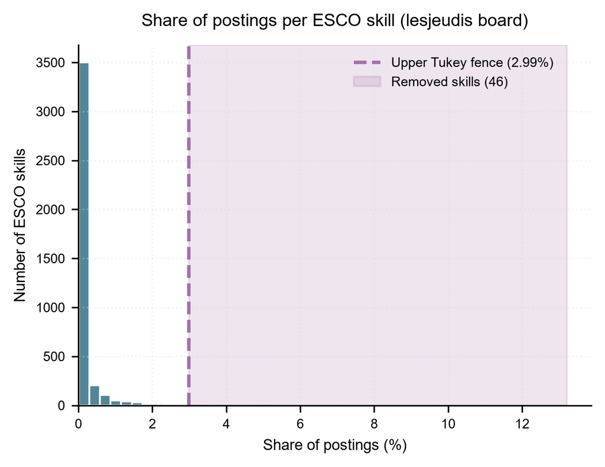

Figure 1: Share of postings per ESCO skill on lesjeudis. The dashed line is the upper Tukey fence (2.99%); the 46 skills above it are removed in version Dv3.

It should be noted that the Tukey fence was applied to ESCO skills only, because the Lightcast block contains only a few terms (20 occur in the lesjeudis postings, 12 in jobs.de and 32 in jobbland).

**Step 3.** We next wanted to keep the most useful skills, in the sense of them being associated with similar types of jobs, and at the same time remove skills that appear in very different types of jobs and are therefore less helpful in the clustering of job titles. In other words, similarly to Step 2, this approach aims to remove generic skills, but this time by examining their variance rather than their frequency alone. For example, the skill “Communication” might appear across many, irrelevant job types, whereas “Machine learning” might appear frequently within data analysis jobs but rarely elsewhere, and would therefore be considered more useful for distinguishing those jobs.

For this purpose, we use the similarity between job titles as an indication of how closely related two postings are, represented in a k-nearest-neighbour (k-NN) graph. The graph forms a network of job postings in which each posting is connected to its k most similar postings, based on their title embeddings. We set k = 5, meaning that each posting is linked to its five most similar postings. We chose a small neighbourhood because we want to assess how closely a skill is associated with the most similar job titles, rather than with a broader set of jobs. A link exists if either posting is among the other’s neighbours.

To evaluate whether a skill tends to appear in similar job postings, we use the Laplacian Score (He et al. 2005). This is an unsupervised feature-selection method that scores each feature by how well its values agree with a neighbourhood graph of the samples. In our case the samples are the job postings, and each skill is a feature, i.e. a variable that is equal to 1 for the postings tagged with the skill and 0 for all others. We chose the method because we have no labels on the job postings - so an unsupervised method is needed - and because it measures directly, for each skill, whether the postings tagged with it are neighbours in the title embedding space.

The skills and terms that correspond to each posting were identified before the clustering, separately for each board. ESCO skills were extracted using an extractor (Kavargyris et al. 2025) that splits the full text (title and description) into short fragments and compares each fragment with the ESCO skill descriptions (script 69b); a skill is assigned to the posting when the similarity reaches 0.6.

The Lightcast terms were assigned through a process of exact phrase matching of the terms selected from the Lightcast list on the same text (script 91): the text was lower-cased, hyphens and slashes were read as spaces, whole words were matched, and an optional plural ending (-s or -es) was allowed. Each term was matched independently, so e.g. a text in a posting that reads “supply chain management” will match both the “supply chain” and “supply chain management” skill.

The final result is, for each board, two files, containing a list of skills and a list of terms for each posting respectively, from which the vectors in step (a) are built, e.g.:

**Lightcast terms**

```json
{
  "id": "1680874",
  "day": "2024-01-30",
  "terms": [
    "Supply Chain"
  ]
}
```

**ESCO skills**

```json
{
  "id": "1680874",
  "day": "2024-01-30",
  "skills": [
    "http://data.europa.eu/esco/skill/1a3660c2-…-529afc305428",
    "http://data.europa.eu/esco/skill/68269b0a-…-a0b0230fe60c",
    "http://data.europa.eu/esco/skill/70159320-…-99e0adf3f77e"
  ]
}
```

For every item (ESCO skill or Lightcast term), we use the Laplacian score to assess how close the postings that carry it are in the k-NN graph. A low score means that the postings of the skill are neighbours of each other; a score of about 1 means that they are only randomly positioned in the graph. More specifically, the score is below 1 only when the postings that carry the skill have more links among themselves than expected by chance, and above 1 when they have fewer. A skill that occurs in a single posting has no links to other carriers and therefore scores just above 1; the same applies to most rare skills. The calculation involves the following steps:

(a) For each item (skill or term), we create a vector with one entry per posting of the graph (n entries for n postings), which takes the value 1 if the posting carries the item and 0 if it doesn’t. This vector is the feature $f$.

(b) For each link connecting the postings in the graph, we calculate its weight, which is equal to:

$$w_{ij} = \exp\left(-\frac{d_{ij}^{2}}{t}\right)$$

where:

- $d_{ij}$ is the Euclidean distance between the title embeddings of postings $i$ and $j$.

Since the embeddings are unit-length vectors, the squared distance can be calculated from the cosine similarity as:

$$d_{ij}^{2} = 2\,\left(1 - \cos(\theta_{ij})\right)$$

where $\cos(\theta_{ij})$ is the cosine similarity between the two job-title embeddings, with similar titles having a close distance.

where $\mathcal{E}_{\mathrm{diff}}$ denotes the set of graph edges connecting postings with different titles.

(c) We calculate the weighted mean of each skill and center the skill vector by extracting it from the original 0 and 1 values:

$$z_i=x_i-\bar{x}_w$$

This results in postings carrying the skill being positive and postings not carrying it negative.

(d) We finally calculate the Laplacian score, equal to:

$$S = \frac{N}{D}$$

where:

- The numerator is the weighted differences in skill values across graph links:

$$N = \sum_{(i,j)\in E} w_{ij}(x_i-x_j)^2$$

where:

- $E$ is the set of graph links.
- $w_{ij}$ is the weight of the link between postings $i$ and $j$.
- $x_i$ and $x_j$ are the binary skill indicators (0 or 1) for postings $i$ and $j$, respectively.
- The denominator is the overall weighted variation in skill values across all postings:

$$D = \sum_i d_i(x_i-\bar{x}_w)^2$$

where:

- $d_i$ is the weighted degree of posting $i$, calculated as the sum of the weights of its connected links.
- $x_i$ is the binary skill indicator for posting $i$.
- $\bar{x}_w$ is the weighted mean of the skill indicators across all postings.

A lower score indicates that postings containing the skill tend to be connected to other postings containing the same skill. A higher score indicates that the skill is more spread out across the graph.

In the below example, assuming that in the k-NN graph (a) Data Scientist, Data Analyst and ML Engineer job titles are closely connected and (b) HR Manager, Recruiter and HR Assistant are also closely connected, the “communication” skill appears in two technology-related postings, as well as two HR-related postings; as its occurrence is spread across different types of jobs, it is less closely aligned with the graph structure and we would expect it to receive a higher Laplacian Score than e.g. “Python”, which appears only in technology-related postings.

Table 3: Binary representation of skills across job postings

| Sample (job posting) | Python | Data analysis | Communication |
| --- | --- | --- | --- |
| Data Scientist | 1 | 1 | 1 |
| Data Analyst | 1 | 1 | 1 |
| ML Engineer | 1 | 0 | 0 |
| HR Manager | 0 | 0 | 1 |
| Recruiter | 0 | 0 | 1 |
| HR Assistant | 0 | 0 | 0 |

**Step 4.**In the original Laplacian Score paper, the algorithm calculates a score for every feature and sorts the features from the lowest score (best) to the highest; it is then left to the user to keep the top m features. Therefore, in order to determine the threshold m for deciding which features to keep, we compared the clustering for thresholds 0.7, 0.8, 0.9 and 1.0 on lesjeudis, using as criteria the silhouette score and the noise.

The results showed that a Laplacian score threshold of 1.0 kept about half of the ESCO skills (49% to 50%): these are the skills whose postings have more links among themselves than expected by chance, whereas the other half, mostly rare skills whose postings are not linked to each other, score just above 1. The threshold 0.8 gave the lowest noise and the highest silhouette in the UMAP space for Dv2, and it was therefore decided to be used for both versions and all boards. This keeps 518 (Dv2) and 500 (Dv3) of the ESCO skills on lesjeudis, 382 and 369 on jobs.de, and 449 and 443 on jobbland. Regarding Lightcast, it kept 6 terms on lesjeudis, 0 on jobs.de and 1 on jobbland.

The tables in Section 1.3 show the 15 skills with the lowest score and the 15 most frequent skills for the jobbland board. The lowest scores belong mostly to skills with few postings whose postings carry similar titles, for example mystery shopping. Of the 15 most frequent skills, only one (“sales activities”) is kept in Dv2: these skills are spread over many titles and their scores lie between 0.76 and 0.93.

It is important to note that the score measures whether the postings of a skill are concentrated among similar titles, not whether the skill was assigned correctly. A wrongly assigned skill whose postings happen to share similar titles also scores low (for example “improve chemical processes”, whose most common job ad assignment is “junior audit consultants”, see Section 1.3 for more details). We therefore use the score as a filter for skills that are concentrated among similar titles, and not as a check of the skill tagging process itself. The frequency cut and the Laplacian score also act on different skills; for example, “give interviews to media” (1,379 postings) is kept by the Laplacian score but removed by the Tukey frequency cut in Dv3 as it is too common (its occurence is above the defined threshold). Such skills can come from generic wording (for example “improvements that can develop their processes” returning “improve chemical processes”) or from the hiring-process text of advertisements (the word “interviews” returning “give interviews to media”), which is why a low score does not mean that the skill was assigned correctly.

##### Results

We compared the three input variations on lesjeudis.com with two criteria from the literature on text clustering with embeddings. The first is the silhouette (Rousseeuw 1987), calculated in the 10-dimensional UMAP space, which is the space in which each input was clustered. In simple terms, the silhouette measures how compact the clusters are in the space they take up. The pipeline followed was:

1. Each job posting starts as a 1,024-dimension title embedding.
2. We use UMAP to reduce it to 10 dimensions. Each posting is now a point with 10 coordinates, while setting `min_dist = 0` leads to similar points being closer together.
3. We then apply HDBSCAN to those 10-dimensional points, looking for dense groups, while the loose points are labelled as noise.
4. The silhouette then examines, for each clustered job posting, whether it is closer to its own cluster than to the nearest other cluster, using distances between those 10-dimensional points.

The silhouette coefficient measures how well an observation fits within its assigned cluster relative to the nearest alternative cluster. It ranges from -1 to +1, with higher values indicating better-defined cluster assignments.

For an individual observation, the silhouette coefficient is calculated as:

$$s(i) = \frac{b(i)-a(i)}{\max(a(i),b(i))}$$

where $a(i)$ represents the average distance between observation $i$ and the other observations in its assigned cluster, and $b(i)$ represents the lowest average distance between observation $i$ and the observations in another cluster (i.e. the nearest alternative cluster).

Silhouette scores were calculated in the 10-dimensional UMAP space, using Euclidean distance.

The second criterion is topic coherence (C<sub>NPMI</sub>), which is a standard semantic measure used for clusters of text (Röder et al. 2015; Grootendorst 2022). We use it in addition to the silhouette because the silhouette only measures how compact the clusters are in the space in which they were formed, which is partly the result of the UMAP clustering itself and, for input D, also reflects the skills added to the title embedding. Topic coherence, on the other hand, is calculated only from the words of the titles in each cluster (so it does not depend on that space), and checks whether the titles of a cluster share a common vocabulary, as would be expected from postings of the same occupation. For each cluster we took the ten words with the highest class-based tf-idf score in its titles (Grootendorst 2022) and calculated the mean normalised pointwise mutual information (Bouma 2009) over all pairs of these words. Each title of the board counts as one document. The values of the clusters of an input are summarised by their median; for example, C<sub>NPMI</sub> is −1 when two words never occur in the same title and +1 when they always do.

| Input | Clusters | Noise | Silhouette | Median C<sub>NPMI</sub> |
| --- | --- | --- | --- | --- |
| A | 144 | 30.9% | 0.618 | −0.389 |
| D v2 | 129 | 11.9% | 0.787 | −0.527 |
| D v3 | 117 | 33.3% | 0.617 | −0.355 |

According to the silhouette score, input D v2 is the preferred choice (0.787 against 0.618 for A, in the UMAP space), and it also has the least noise. In input D, however, the clustering space includes the ESCO skills and Lightcast terms, so postings can be closer in the embedding space not because their titles are similar but because of their skills.

It is therefore expected that topic coherence (C<sub>NPMI</sub>), which looks only at the words of the titles, gives the opposite result: D v2 has the lowest values (median C<sub>NPMI</sub> −0.527 against −0.389 for A), which means that the titles inside its clusters share fewer words than those of A. The reason is that skills can be unreliable because of how they are extracted. The esco-skill-extractor turns each piece of a posting into a vector with a small sentence model (all-MiniLM-L6-v2) and compares it with the vector of every ESCO skill description. A skill counts as found when the similarity reaches 0.6. In the first version of input D (D v1), which had no filter on the skills, this produced false matches such as the skill “feed concrete mixer” on IT consultants’ postings. This can be due to (a) generic wording, because a common sentence of a job advert such as “supply the client with…” or “ensure delivery of…” can be similar in meaning in the context of a skill description or (b) employer templates, because one sentence repeated in a group of postings, such as a company description, gives the same skill to all of them. As already explained, the Laplacian Score filter was introduced exactly for this purpose, i.e. to remove skills whose postings have unrelated titles.

C<sub>NPMI</sub> is negative for all three inputs. This can be explained by the fact that titles are very short pieces of text, and the top words of a cluster are mostly alternative words for the same role (for example “buyer” and “purchasing”) or rare tokens which rarely occur in the same title. In the lesjeudis board, about one fifth of the titles (at least 21.7%) contain French, so some of the top words are French equivalents of English ones (for example “buyer” and “acheteur”). The values are therefore compared with each other and not interpreted in absolute terms. The silhouette and C<sub>NPMI</sub> are calculated on the same clusters, so the numbers of clusters and noise are the same in both (for example 129 clusters for D v2).

Input D v3 is similar to A on silhouette and topic coherence (silhouette 0.617 against 0.618; median C<sub>NPMI</sub> −0.355 against −0.389) but requires additional computation steps and choices of variables (ESCOX skill extractor, Laplacian score threshold, k-nearest-neighbours, Tukey boxplot to identify outliers). We therefore decided to use input A for the generation of the clustering embeddings.

#### Clustering algorithms tested

Using the embeddings of Case A (i.e. extracted only from the title) as input, we next compared the results of four clustering algorithms on the postings:

1. HDBSCAN with excess-of-mass (EOM) cluster selection
2. HDBSCAN with leaf cluster selection
3. k-means
4. Ward agglomerative clustering.

The comparison was conducted on the three job-posting platforms that had already been chosen due to their data completeness over time (LesJeudis, Jobbland and Jobs.de).

##### Evaluation criteria

Clustering quality was assessed using the silhouette coefficient (similarly to the input comparison conducted earlier), calculated on a random sample of 10,000 postings.

Since HDBSCAN can leave observations unassigned, the proportion of postings classified as noise was reported alongside its silhouette scores. This was important because the silhouette is calculated only for observations assigned to clusters, meaning that an algorithm could obtain a relatively high score by excluding difficult-to-cluster postings. To address this issue further, k-means and Ward were also evaluated on the subset of postings assigned to clusters by HDBSCAN EOM, allowing their silhouette scores to be compared on the same observations.

#### HDBSCAN EOM and leaf selection

Table 1 reports the number of clusters, noise proportion and silhouette scores obtained using HDBSCAN EOM and leaf selection across the three datasets.

**Table 1. HDBSCAN EOM and leaf comparison across datasets (input A)**

| Dataset | EOM clusters | EOM noise (%) | EOM silhouette (UMAP) | Leaf clusters | Leaf noise (%) | Leaf silhouette (UMAP) |
| --- | --- | --- | --- | --- | --- | --- |
| LesJeudis | 144 | 30.9 | 0.618 | 151 | 32.5 | 0.633 |
| Jobbland | 357 | 34.3 | 0.618 | 391 | 40.3 | 0.639 |
| Jobs.de | 71 | 27.6 | 0.542 | 84 | 38.8 | 0.590 |

*Note: Silhouette scores are calculated in the 10-dimensional UMAP space. Noise percentages refer to the proportion of postings not assigned to a cluster.*

The results show that HDBSCAN leaf selection produced more clusters and a higher proportion of noise than EOM on all three boards, while providing only small improvements in UMAP silhouette scores. Leaf selection produced between 7 and 34 additional clusters and between 1.6 and 11.2 percentage points more noise, while the silhouette in UMAP space rose by only 0.015 to 0.048. It was therefore retained as an alternative specification for sensitivity analysis rather than selected as the main approach.

#### Comparison of HDBSCAN EOM with k-means and Ward agglomerative clustering

Table 2 presents the silhouette scores for k-means and Ward clustering, using the same number of clusters as HDBSCAN EOM. The final two columns report the scores obtained when these methods were evaluated only on the subset of postings assigned to clusters by HDBSCAN EOM.

**Table 2. Silhouette comparison of k-means and Ward clustering (input A)**

| Dataset | k-means (UMAP) | Ward (UMAP) | k-means (EOM subset) | Ward (EOM subset) |
| --- | --- | --- | --- | --- |
| LesJeudis | 0.467 | 0.461 | 0.576 | 0.593 |
| Jobbland | 0.438 | 0.433 | 0.577 | 0.587 |
| Jobs.de | 0.431 | 0.417 | 0.519 | 0.528 |

*Note: All silhouette scores are calculated in the 10-dimensional UMAP space. The first two columns report scores for all postings, and the final two columns report scores calculated on the subset of postings assigned to clusters by HDBSCAN EOM.*

The results show that k-means and Ward obtained lower silhouette scores than HDBSCAN EOM on all three boards when all postings were required to be assigned to a cluster. However, when evaluated on the same postings retained by HDBSCAN, the differences became smaller. For example, on jobbland.se, the UMAP silhouette score was 0.618 for HDBSCAN EOM, against 0.438 for k-means and 0.433 for Ward on all postings, and 0.577 and 0.587, respectively, on the postings retained by HDBSCAN. This shows that HDBSCAN’s ability to leave observations that are difficult to cluster (i.e. noise) unassigned is an important factor behind its higher silhouette scores.

### 1.2.1 Selection of HDBSCAN Hyperparameters

Following the selection of HDBSCAN EOM, a second stage examined the sensitivity of the clustering results in the choice of two hyperparameters: `min_cluster_size` and `min_samples`.

The `min_cluster_size` parameter specifies the minimum number of observations required for a group to be considered a cluster. The `min_samples` parameter controls the density requirement for observations to be assigned to a cluster rather than classified as noise. Increasing `min_samples` generally makes the clustering more conservative, as a higher local density is required for observations to be considered part of a cluster.

The experiments were conducted using the LesJeudis dataset and the input embeddings of case A (titles of job postings only). The initial grid comprised five parameter combinations: (10, 10), (20, 10), (20, 20), (40, 10) and (40, 40), where the first value denotes `min_cluster_size` and the second denotes `min_samples`. The grid was then extended to include (80, 20) and (80, 40), in order to investigate whether larger minimum cluster sizes could produce fewer, more substantial clusters.

The resulting solutions were compared using several criteria:

- **Number of clusters:** to assess the overall level of detail of the clustering.
- **Percentage of noise observations:** the proportion of postings that HDBSCAN did not assign to any cluster, indicating how restrictive the density requirements were.
- **Median cluster size:** to assess the typical size of the resulting clusters.
- **Number of small clusters:** the number of clusters containing fewer than 60 postings, providing an indication of how many relatively small groups were produced.
- **Relative validity:** HDBSCAN’s internal density-based validity measure, used as an additional indicator of clustering quality.
- **Named-occupation coverage:** an exploratory check of whether four manually identified occupation titles in the LesJeudis dataset (three related to export control and one to semiconductor occupations) were assigned to clusters rather than classified as noise.

The objective was not simply to maximise the number of clusters or minimise the proportion of noise. Rather, the aim was to identify a reasonable balance between cluster granularity, cluster size, the retention of observations and internal clustering quality. Particular attention was paid to avoiding an excessive number of small clusters, given the requirements of the subsequent occupational analysis.

#### Hyperparameter sensitivity results

Table 4 reports the results of the extended hyperparameter grid, using the second experimental run conducted on 18 November.

**Table 4. HDBSCAN hyperparameter sensitivity analysis (LesJeudis, Input A)**

| `min_cluster_size` | `min_samples` | Clusters | Noise (%) | Median size | Clusters below 60 postings |
| --- | --- | --- | --- | --- | --- |
| 10 | 10 | 413 | 28.9 | 24 | 371 |
| 20 | 10 | 265 | 29.0 | 40 | 197 |
| 20 | 20 | 227 | 33.4 | 44 | 157 |
| **40** | **10** | **144** | **30.9** | **72** | **51** |
| 40 | 40 | 108 | 42.3 | 77 | 34 |
| 80 | 20 | 57 | 36.0 | 157 | 0 |
| 80 | 40 | 51 | 39.7 | 187 | 0 |

*Note: The selected baseline configuration is highlighted. A small cluster is defined here as a cluster containing fewer than 60 postings.*

The results indicated that reducing `min_cluster_size` substantially increased the number of clusters without producing a corresponding improvement in the proportion of observations retained. For example, with `min_samples=10`, reducing `min_cluster_size` from 40 to 20 and 10 increased the number of clusters from 144 to 265 and 413, respectively, while the noise proportion remained broadly similar (approximately 29–31%). The resulting solutions also contained a considerable number of small clusters: 371 of the 413 clusters in the (10, 10) configuration contained fewer than 60 postings.

Conversely, increasing both parameters produced fewer and larger clusters, but this came at a cost. The extended grid showed that the (80, 20) and (80, 40) configurations produced 57 and 51 clusters, respectively, compared with 144 for the baseline configuration (40, 10). However, these solutions also classified a larger proportion of postings as noise (36.0% and 39.7%, respectively) and obtained lower relative validity scores (0.205 and 0.182, compared with approximately 0.28 for the smaller configurations).

#### Internal validity and named-occupation coverage

Table 5 presents the additional evaluation measures recorded during the second experimental run, including relative validity and the named-occupation coverage check.

**Table 5. Relative validity and named-occupation coverage**

| Configuration (`min_cluster_size` / `min_samples`) | Relative validity | Named titles in clusters |
| --- | --- | --- |
| 10 / 10 | 0.279 | 2/4 |
| 20 / 10 | 0.287 | 3/4 |
| 20 / 20 | 0.252 | 1/4 |
| 40 / 10 | Not reported | Not reported |
| 40 / 40 | 0.255 | 1/4 |
| 80 / 20 | 0.205 | 2/4 |
| 80 / 40 | 0.182 | 2/4 |

*Note: The 40/10 baseline metrics were not reported in the second-run results for relative validity and named-occupation coverage.*

The relative validity scores were generally higher for the smaller configurations, particularly (20, 10), which obtained a score of 0.287. The larger configurations (80, 20) and (80, 40) produced lower scores of 0.205 and 0.182, respectively. This provided additional evidence that the reduction in cluster count achieved through larger minimum cluster sizes came at the expense of internal density-based validity.

The named-occupation coverage check did not provide sufficiently strong evidence to distinguish between parameter combinations. Only four relevant titles were available in the LesJeudis dataset, making the results sensitive to the classification of individual postings. This measure was therefore treated as descriptive rather than as a formal validation criterion.

#### Repeated execution and reproducibility

Repeated executions of the experimental grid also produced some differences in clustering statistics despite the use of fixed random seeds. For example, the (40, 40) configuration produced 103 clusters and 36.6% noise in the first execution, compared with 108 clusters and 42.3% noise in the second. Similarly, the (20, 10) configuration produced 259 and 265 clusters in the two executions, respectively.

These differences indicate that the results should be interpreted as approximate comparisons between parameter configurations rather than perfectly deterministic outcomes. Accordingly, the selection considered the overall patterns across configurations rather than small differences in individual metrics. The precise source of the run-to-run variation was not established.

#### Hyperparameter selection

On balance, the original configuration of `min_cluster_size=40` and `min_samples=10` was retained. It provided a reasonable compromise between cluster granularity and cluster size, without producing the excessive number of small clusters observed under lower minimum cluster sizes or the increased noise and lower internal validity associated with larger configurations.

The alternative configurations were therefore treated as sensitivity tests rather than replacements for the baseline specification. The hyperparameter experiments were conducted on the LesJeudis dataset only. Consequently, the results provide an assessment of parameter sensitivity for this dataset rather than evidence that the same relative performance holds across all job-posting platforms.

### 1.2.2 Chosen Clustering Specification

Based on the comparative algorithm assessment and subsequent hyperparameter sensitivity analysis, the final clustering configuration consisted of input A, reduced to 10 dimensions using UMAP, followed by HDBSCAN with excess-of-mass (EOM) cluster selection. The HDBSCAN parameters were set to `min_cluster_size=40` and `min_samples=10`.

This configuration was retained because it provided a reasonable balance between cluster granularity, cluster size, the proportion of postings assigned to clusters and the interpretability requirements of the subsequent occupational analysis. The selection was therefore based on a combination of quantitative clustering metrics and substantive considerations regarding the occupational meaning of the resulting groups, rather than on the maximisation of a single internal validation metric.

## 1.3 Appendix: Laplacian Score of the ESCO skills on jobbland

This appendix shows the Laplacian Score of the ESCO skills on the Swedish board (53,959 postings), computed with the graph and the score defined in the section “Removing generic skills (Dv3)” (k = 5 nearest neighbours by title embedding, heat-kernel constant t = 0.1374). All 6,539 skills that occur in at least one posting are scored. A skill is kept when its score is below 0.8; 449 skills (6.9%) are kept. The median score is 1.000, that is, for most skills the postings that carry the skill are no closer to one another on the graph than postings drawn at random. A skill that occurs in one posting always scores about 1 and is never kept; skills with two or more postings can be kept.

Table 4: Skills by number of postings: how many are scored, the share kept (score below 0.8), the median score, the median share of the most common title among the postings that carry the skill, and the median number of distinct titles per posting.

| postings per skill | skills | below threshold | median score | median share of the most common title | median distinct titles per posting |
| --- | --- | --- | --- | --- | --- |
| 1 to 2 | 2,028 | 2% | 1.000 | 100% | 1.00 |
| 3 to 4 | 847 | 9% | 1.000 | 33% | 1.00 |
| 5 to 9 | 1,011 | 7% | 1.000 | 17% | 1.00 |
| 10 to 19 | 801 | 7% | 0.963 | 10% | 1.00 |
| 20 to 49 | 852 | 9% | 0.946 | 6% | 0.96 |
| 50 to 199 | 701 | 12% | 0.920 | 4% | 0.93 |
| 200 or more | 299 | 17% | 0.885 | 2% | 0.90 |

The share of skills that are kept rises with the number of postings, from 2% for skills with one or two postings to 17% for skills with 200 or more (Table 4). Skills with one to four postings are 2,875 of the 6,539 scored skills (44%) and, from the rounded shares in the table, about 115 of the 449 kept skills.

### 1.3.1 Lowest scores

Table 5 lists the 15 lowest scores. These are skills whose postings concentrate on a few neighbouring titles, for example “station manager”, “medical nurse”, “mystery shopper” and “optician”. The score measures concentration, not correctness: a skill is kept when the postings that carry it have similar titles, whether or not the skill is really required in them. Eight of the 15 skills have 10 or fewer postings, and for some the most common title accounts for a large share of the postings (100% for “transfer animal embryos”), which is consistent with repeated advertisements.

Table 5: The 15 lowest Laplacian Scores of the ESCO skills on jobbland (identical for D v2 and D v3). Postings: number of postings that carry the skill.

| # | skill | postings | score | most common title (share of these postings) | decision |
| --- | --- | --- | --- | --- | --- |
| 1 | sell optical products | 17 | 0.127 | station manager (59%) | kept |
| 2 | monitor vehicle maintenance activities | 10 | 0.192 | station manager (80%) | kept |
| 3 | blockchain | 10 | 0.198 | project-based cto-cloud architect / fullstack (10%) | kept |
| 4 | operate patients with thoracic diseases | 18 | 0.205 | medical nurse (39%) | kept |
| 5 | perform mystery shopping | 27 | 0.236 | mystery shopper to visit (30%) | kept |
| 6 | improve chemical processes | 37 | 0.238 | junior audit consultants (38%) | kept |
| 7 | practice martial arts | 7 | 0.239 | insider - change an entire industry (43%) | kept |
| 8 | complete administration | 15 | 0.242 | postman/parcel courier (47%) | kept |
| 9 | operate water-heating equipment | 5 | 0.243 | data center facilities technician, mechanical (20%) | kept |
| 10 | transfer animal embryos | 3 | 0.246 | vocational training for pet technician with g (100%) | kept |
| 11 | advise patients on vision improvement conditions | 12 | 0.265 | leg. optician (67%) | kept |
| 12 | show impartiality in an assessment situation | 72 | 0.269 | summer staff (68%) | kept |
| 13 | schedule gaming tables | 4 | 0.284 | 🇷🇴 swedish-speaking game presenters in beauti (25%) | kept |
| 14 | repair windshield wipers | 8 | 0.299 | salesman thansen (50%) | kept |
| 15 | repair crane equipment | 3 | 0.325 | senior specialist technical service - equipme (67%) | kept |

#### Comments

The score cannot remove a wrong skill that is repeated across similar postings, because such a skill looks like a specific one. We checked two skills in detail (script 127), where each sentence was given as input to the extractor separately. The results were:

- Skill “give interviews to media” (found in 1,379 postings, with 1,230 distinct titles in total, Laplacian score 0.482). In all sampled postings the match comes from the word “interviews” in a sentence about the hiring process.
- Skill “improve chemical processes” (found in 37 postings, Laplacian score 0.238). In this case, there are four postings from one firm (EY) that have a (boilerplate) sentence about “providing suggestions on improvements that can develop their processes”. In another example, a data analyst ad describes “automates and enhances processes”, which also leads to the specific skill assignment. Of the postings examined, only one was found to be a true match.

We conclude that both skills come from generic wording that the extractor (threshold 0.6) maps to a specific ESCO skill. A low Laplacian Score in this case therefore is not evidence that the skill was extracted correctly.

### 1.3.2 Most frequent skills

The highest scores cannot be ranked meaningfully: more than half of the scored skills have a score of 1.000, and the differences in the third decimal are noise. We therefore show the 15 most frequent skills instead (Table 6 and Table 7).

In D v2 (Table 6) only one of the 15 most frequent skills, “sales activities”, is kept. “Swedish” occurs in 11,168 postings (20.7%) and scores 0.825, just above the threshold. In D v3 the Tukey frequency cut first removes the 51 skills above the fence (the most frequent remaining skill has 957 postings, 1.77%), of which 6 would have been kept by the score; the table shows the most frequent skills after the cut (Table 7). Four of these 15 are kept, three of them with scores close to the threshold (0.761 to 0.798) and “accounting” with 0.553. One of them, “macro-regional strategy” (863 postings, most common title “nurse”), is not a plausible requirement of the postings that carry it.

Table 6: The 15 most frequent ESCO skills on jobbland, D v2 (no frequency cut).

| # | skill | postings | score | most common title (share of these postings) | decision |
| --- | --- | --- | --- | --- | --- |
| 1 | Swedish | 11,168 | 0.825 | nurse (1%) | dropped |
| 2 | recruit personnel | 8,341 | 0.851 | nurse (1%) | dropped |
| 3 | cooperate with colleagues | 7,166 | 0.845 | nurse (1%) | dropped |
| 4 | assume responsibility | 5,065 | 0.875 | nurse (1%) | dropped |
| 5 | communication | 4,460 | 0.883 | car mechanic (1%) | dropped |
| 6 | meet commitments | 4,305 | 0.878 | pharmacist (1%) | dropped |
| 7 | interact verbally in Swedish | 4,046 | 0.896 | personal assistant (0%) | dropped |
| 8 | communicate with customers | 4,023 | 0.839 | inspection technician (0%) | dropped |
| 9 | recruit employees | 3,818 | 0.807 | nurse (1%) | dropped |
| 10 | write Swedish | 3,274 | 0.897 | personal assistant (0%) | dropped |
| 11 | show initiative | 3,236 | 0.929 | nurse (1%) | dropped |
| 12 | sales activities | 2,493 | 0.762 | seller (1%) | kept |
| 13 | innovation processes | 2,378 | 0.897 | mekanikkonstruktör (0%) | dropped |
| 14 | coordinate security | 2,340 | 0.863 | the correctional service is growing - we are (1%) | dropped |
| 15 | maintain relationship with customers | 2,287 | 0.811 | car mechanic (2%) | dropped |

Table 7: The 15 most frequent ESCO skills on jobbland after the Tukey frequency cut, D v3. 6,488 skills are scored and 443 are kept.

| # | skill | postings | score | most common title (share of these postings) | decision |
| --- | --- | --- | --- | --- | --- |
| 1 | provide high quality customer service | 957 | 0.884 | seller (1%) | dropped |
| 2 | promote ideas, products, services | 942 | 0.942 | summer staff (3%) | dropped |
| 3 | design customer experiences | 911 | 0.798 | happy employees (2%) | kept |
| 4 | tend to elderly people | 899 | 0.840 | nurse (3%) | dropped |
| 5 | organise homecare for patients | 886 | 0.761 | nurse (5%) | kept |
| 6 | entrepreneurship | 867 | 0.898 | pharmacist (1%) | dropped |
| 7 | macro-regional strategy | 863 | 0.796 | nurse (2%) | kept |
| 8 | continuous improvement philosophies | 863 | 0.919 | quality engineer (1%) | dropped |
| 9 | solve technical problems | 816 | 0.893 | technical project manager (1%) | dropped |
| 10 | accounting | 810 | 0.553 | accounting economist (5%) | kept |
| 11 | solve problems | 803 | 0.947 | nurse (1%) | dropped |
| 12 | management consulting | 783 | 0.830 | consultant manager (1%) | dropped |
| 13 | contact customers | 756 | 0.931 | seller (1%) | dropped |
| 14 | manage relationships with stakeholders | 749 | 0.883 | project manager (2%) | dropped |
| 15 | write English | 737 | 0.915 | researcher (1%) | dropped |

## References

Bouma, Gerlof. 2009. “Normalized (Pointwise) Mutual Information in Collocation Extraction.” *From Form to Meaning: Processing Texts Automatically. Proceedings of the Biennial GSCL Conference 2009*, 31–40.

Grootendorst, Maarten. 2022. *BERTopic: Neural Topic Modeling with a Class-Based TF-IDF Procedure*. https://arxiv.org/abs/2203.05794.

He, Xiaofei, Deng Cai, and Partha Niyogi. 2005. “Laplacian Score for Feature Selection.” In *Advances in Neural Information Processing Systems*, edited by Y. Weiss, B. Schölkopf, and J. Platt, vol. 18. MIT Press. https://proceedings.neurips.cc/paper_files/paper/2005/file/b5b03f06271f8917685d14cea7c6c50a-Paper.pdf.

Kavargyris, Dimitrios Christos, Konstantinos Georgiou, Eleanna Papaioannou, Konstantinos Petrakis, Nikolaos Mittas, and Lefteris Angelis. 2025. “ESCOX: A Tool for Skill and Occupation Extraction Using LLMs from Unstructured Text.” *Software Impacts* 25 (June): 100772. https://doi.org/10.1016/j.simpa.2025.100772.

Röder, Michael, Andreas Both, and Alexander Hinneburg. 2015. “Exploring the Space of Topic Coherence Measures.” *Proceedings of the Eighth ACM International Conference on Web Search and Data Mining*, WSDM ’15, 399–408. https://doi.org/10.1145/2684822.2685324.

Rousseeuw, Peter J. 1987. “Silhouettes: A Graphical Aid to the Interpretation and Validation of Cluster Analysis.” *Journal of Computational and Applied Mathematics* 20: 53–65. https://doi.org/10.1016/0377-0427(87)90125-7.

Tukey, John W. 1977. *Exploratory Data Analysis*. Addison-Wesley.

## Footnotes

[^1]: The HHI (Herfindahl–Hirschman index) is a number between 0 and 1 that shows how concentrated postings are. For each region (or employer), it takes its share of the cluster’s postings, squares each share, and adds them up. It is near 0 when postings are spread over many regions and equals 1 when they all sit in one. For example, if 3 regions hold 50%, 30% and 20% of a cluster’s postings, the HHI is 0.25 + 0.09 + 0.04 = 0.38; whereas if all postings were in one region it would be 1.